# Humidex and physiology during low activity

Author

Alessandro Fuschi

## Setup

```r
library(tidyverse)
cfg <- list(
  data_dir = file.path("data", "5min"), timezone = "UTC",
  analysis_start_date = as.Date("2025-03-01"), max_steps = 10,
  humidex_bin_width = 2, humidex_breaks = c(-Inf, 20, 30, 40, Inf),
  minimum_participants = 10
)

theme_set(theme_minimal(base_size = 12))
outcomes <- c("heartrate", "breathrate", "oxygen", "systolic", "diastolic", "bodytemp", "skintemp")
outcome_labels <- c(
  heartrate = "Heart rate (bpm)", breathrate = "Breathing rate (breaths/min)",
  oxygen = "Oxygen saturation (%)", systolic = "Systolic pressure (mmHg)",
  diastolic = "Diastolic pressure (mmHg)", bodytemp = "bodytemp (sensor units)",
  skintemp = "skintemp (sensor units)"
)
```

## Scope

Physiology versus personal Humidex in five-minute buckets with `0 ≤ step_mean ≤ cfg$max_steps` (currently 10). This exploratory cutoff selects little recorded walking, not verified rest: non-walking exercise and recovery from earlier activity remain possible. `step_mean` averages repeated readings; it is not their sum.

Study window: `2025-03-01 < date < Sys.Date()` (UTC). Humidex is calculated from MyAir temperature and humidity, assuming the instrument accompanies the participant.

## Local data

```r
if (!exists("myair_5min", inherits = FALSE)) {
  myair_5min <- read_csv(
    file.path(cfg$data_dir, "myair_5min.csv.gz"),
    col_types = cols(userId = col_character(), bucket_5min = col_datetime(), deviceId = col_character(), firmware = col_character()),
    locale = locale(tz = cfg$timezone), na = c("", "NA", "NULL"), show_col_types = FALSE
  )
}
if (!exists("smartwatchhigh_5min", inherits = FALSE)) {
  smartwatchhigh_5min <- read_csv(
    file.path(cfg$data_dir, "smartwatchhigh_5min.csv.gz"),
    col_types = cols(userId = col_character(), bucket_5min = col_datetime(), deviceId = col_character(), firmware = col_character()),
    locale = locale(tz = cfg$timezone), na = c("", "NA", "NULL"), show_col_types = FALSE
  )
}
if (!exists("smartwatchlow_5min", inherits = FALSE)) {
  smartwatchlow_5min <- read_csv(
    file.path(cfg$data_dir, "smartwatchlow_5min.csv.gz"),
    col_types = cols(userId = col_character(), bucket_5min = col_datetime(), deviceId = col_character(), firmware = col_character()),
    locale = locale(tz = cfg$timezone), na = c("", "NA", "NULL"), show_col_types = FALSE
  )
}

exposure <- myair_5min %>%
  select(userId, bucket_5min, air_minutes = observed_minute_n,
         temperature = temperature_mean, humidity = humidity_mean) %>%
  filter(as.Date(bucket_5min, tz = cfg$timezone) > cfg$analysis_start_date,
         as.Date(bucket_5min, tz = cfg$timezone) < Sys.Date()) %>%
  left_join(
    smartwatchhigh_5min %>%
      select(userId, bucket_5min, watch_minutes = observed_minute_n,
             heartrate = heartrate_mean, breathrate = breathrate_mean, oxygen = oxygens_mean),
    by = c("userId", "bucket_5min"), relationship = "one-to-one"
  ) %>%
  left_join(
    smartwatchlow_5min %>%
      select(userId, bucket_5min, steps = step_mean, systolic = bphigh_mean, diastolic = bplow_mean,
             bodytemp = bodytemp_mean, skintemp = skintemp_mean),
    by = c("userId", "bucket_5min"), relationship = "one-to-one"
  ) %>%
  mutate(humidex = ThermIndex::humidex(temperature, humidity))
```

## Low-activity selection

Missing steps are not treated as zero. Each bucket counts once, regardless of its raw-reading count; each physiological variable uses its own available observations.

```r
low_activity <- exposure %>%
  filter(is.finite(humidex), is.finite(steps), between(steps, 0, cfg$max_steps))

tibble(
  selection = c("MyAir buckets in study window", "With finite Humidex", "With Humidex and recorded steps", "Low activity"),
  buckets = c(nrow(exposure), sum(is.finite(exposure$humidex)),
              sum(is.finite(exposure$humidex) & is.finite(exposure$steps)), nrow(low_activity))
) %>%
  knitr::kable(big.mark = ",", caption = "Five-minute buckets retained at each selection step")
```

Five-minute buckets retained at each selection step

| selection | buckets |
| --- | --- |
| MyAir buckets in study window | 1352278 |
| With finite Humidex | 1352278 |
| With Humidex and recorded steps | 1066914 |
| Low activity | 753808 |

```r
physiology <- low_activity %>%
  select(userId, bucket_5min, humidex, all_of(outcomes)) %>%
  pivot_longer(all_of(outcomes), names_to = "outcome", values_to = "value") %>%
  filter(is.finite(value)) %>%
  mutate(
    label = factor(outcome_labels[outcome], levels = outcome_labels),
    humidex_bin = floor(humidex / cfg$humidex_bin_width) * cfg$humidex_bin_width,
    thermal_band = cut(humidex, cfg$humidex_breaks, right = FALSE, labels = c("<20", "20–<30", "30–<40", "≥40"))
  )
```

## Coverage

Humidex bands follow the thresholds described by [Environment and Climate Change Canada](https://www.canada.ca/en/services/environment/weather/severeweather/humidex.html); they do not classify physiological stress or cold stress.

```r
coverage <- physiology %>%
  group_by(label, thermal_band) %>%
  summarise(buckets = n(), participants = n_distinct(userId), .groups = "drop") %>%
  complete(label, thermal_band, fill = list(buckets = 0L, participants = 0L))
```

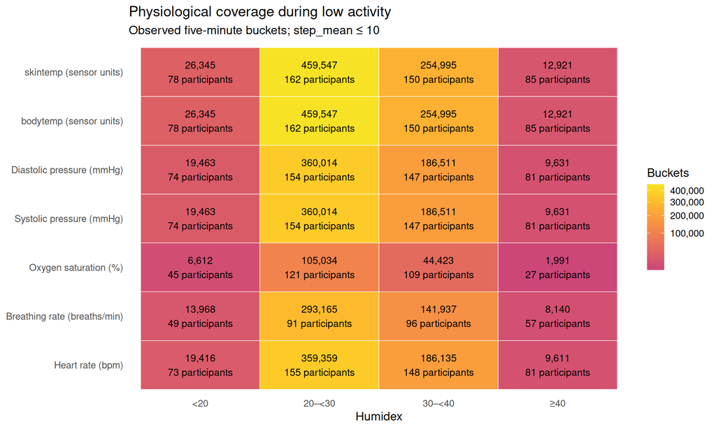

```r
coverage %>%
  ggplot(aes(thermal_band, label, fill = buckets)) +
  geom_tile(color = "white") +
  geom_text(aes(label = paste0(scales::comma(buckets), "\n", participants, " participants")), size = 3.5) +
  scale_fill_viridis_c(option = "C", begin = 0.5, end = 0.95, transform = "sqrt", labels = scales::comma) +
  labs(title = "Physiological coverage during low activity",
       subtitle = paste0("Observed five-minute buckets; step_mean ≤ ", cfg$max_steps),
       x = "Humidex", y = NULL, fill = "Buckets") +
  theme(panel.grid = element_blank())
```

## Physiology by Humidex

Values are averaged within each participant and two-unit Humidex bin, then across participants with equal weight. Only bins with ≥10 participants are plotted to avoid sparse summaries. Participants can differ between bins; no model or significance test is fitted.

```r
participant_profiles <- physiology %>%
  group_by(userId, outcome) %>%
  mutate(personal_mean = mean(value), centered = value - personal_mean) %>%
  group_by(userId, label, humidex_bin) %>%
  summarise(value = mean(value), centered = mean(centered), buckets = n(), .groups = "drop")

profiles <- participant_profiles %>%
  group_by(label, humidex_bin) %>%
  summarise(value = mean(value), centered = mean(centered), participants = n(),
            buckets = sum(buckets), .groups = "drop")

plot_profiles <- profiles %>% filter(participants >= cfg$minimum_participants)
```

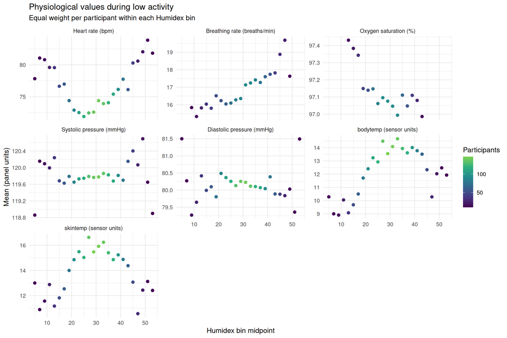

```r
plot_profiles %>%
  ggplot(aes(humidex_bin + cfg$humidex_bin_width / 2, value, color = participants)) +
  geom_point(size = 2) + facet_wrap(~ label, scales = "free_y", ncol = 3) +
  scale_color_viridis_c(end = 0.8) +
  labs(title = "Physiological values during low activity",
       subtitle = "Equal weight per participant within each Humidex bin",
       x = "Humidex bin midpoint", y = "Mean (panel units)", color = "Participants")
```

## Difference from personal mean

The baseline is each participant’s mean for that variable over the retained low-activity buckets. Subtraction reduces differences in individual baseline levels; it does not adjust for time of day, season or recent exercise.

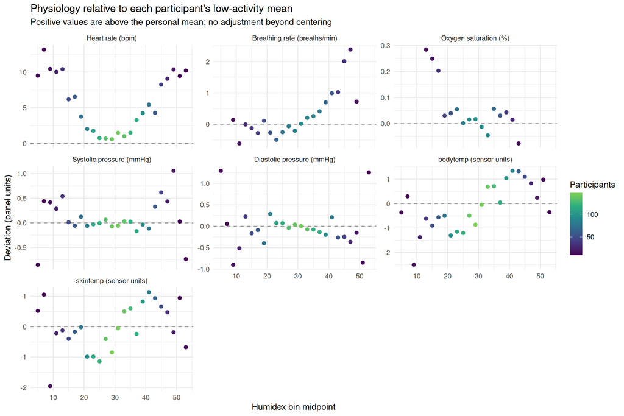

```r
plot_profiles %>%
  ggplot(aes(humidex_bin + cfg$humidex_bin_width / 2, centered, color = participants)) +
  geom_hline(yintercept = 0, linetype = "dashed", color = "grey60") +
  geom_point(size = 2) + facet_wrap(~ label, scales = "free_y", ncol = 3) +
  scale_color_viridis_c(end = 0.8) +
  labs(title = "Physiology relative to each participant's low-activity mean",
       subtitle = "Positive values are above the personal mean; no adjustment beyond centering",
       x = "Humidex bin midpoint", y = "Deviation (panel units)", color = "Participants")
```

## Interpretation

These are descriptive associations, not evidence of heat-induced deterioration. Low step counts do not establish absence of physical activity. Blood-pressure channels are not assumed clinically validated, and body/skin temperature channels retain their recorded sensor units. Changes in oxygen saturation are percentage-point differences.